# Mon document

```r
rownames(data12)[parti==2]
```

```
## [1] "5" "6" "7" "8"
```

```r
rownames(data12)[parti==3]
```

```
## [1] "9"  "10" "11" "12"
```

13. À l’aide de la fonction fviz_dend (package factoextra), afficher un dendrogramme plus joli avec un code couleur différent pour chaque classe de la partition :

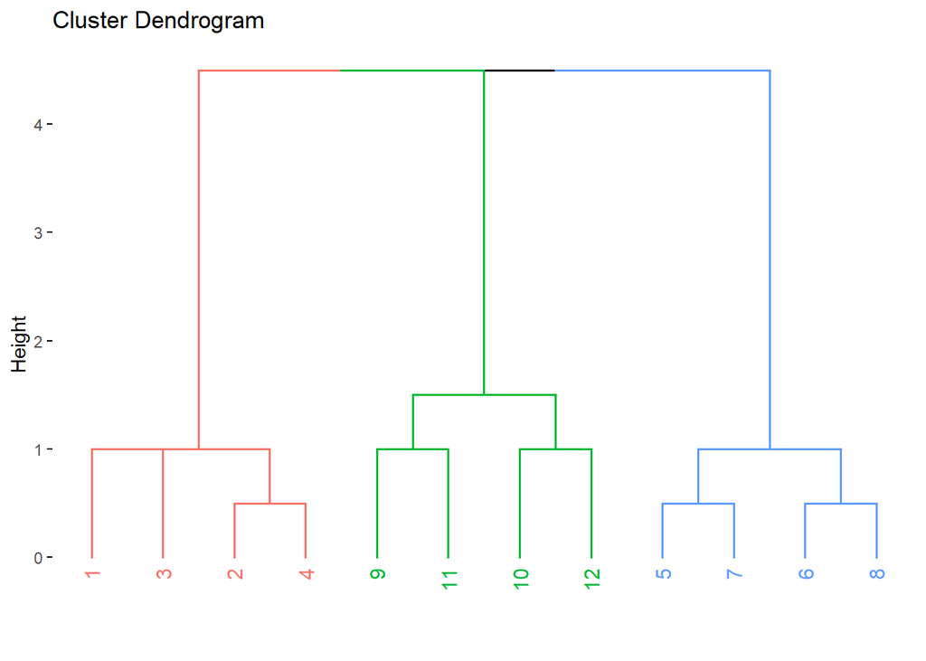

```r
fviz_dend(res.agnes, k=3)
```

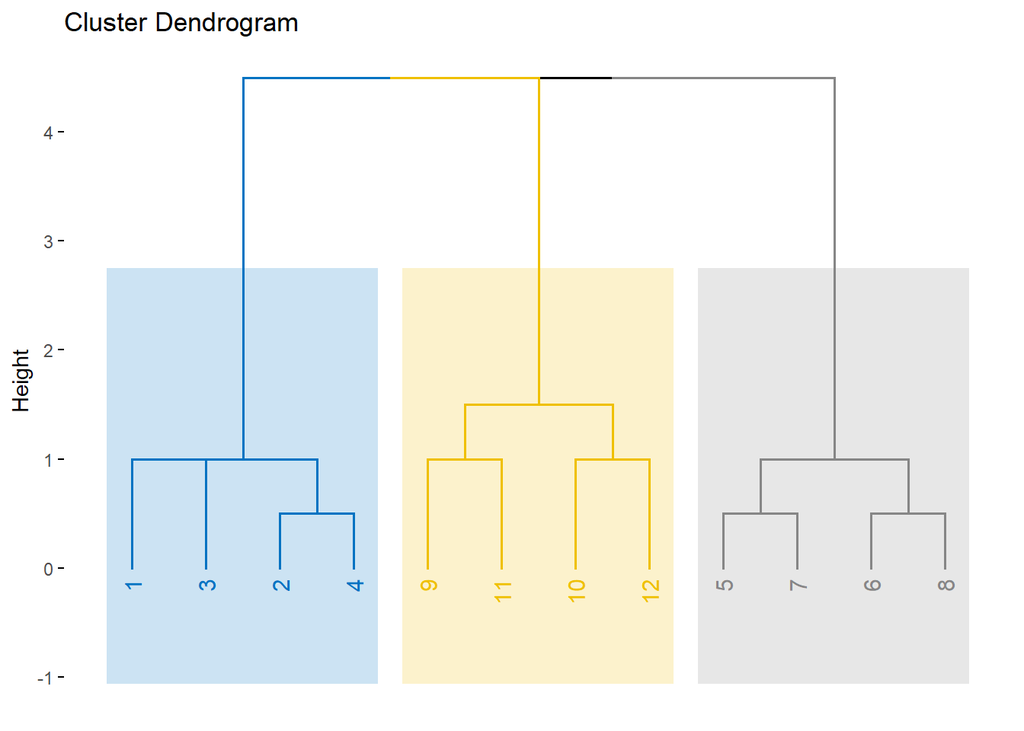

```r
# Ajout de rectangles de couleurs différentes
fviz_dend(
res.agnes,
k=3,
rect = T, rect_fill = T,
palette = "jco", rect_border = "jco"
)
```

14. Enfin, représenter la partition obtenue sur un `biplot`. Une enveloppe convexe est tracée autour de chaque classe. Si le jeu de données comporte plus de 2 variables, alors une ACP est effectuée au préalable puis la partition est représentée dans le plan engendré par les deux premiers axes. Cette représentation nécessite la mise en oeuvre des deux fonctions `hcut` et `fviz_cluster` du package `factoextra`.

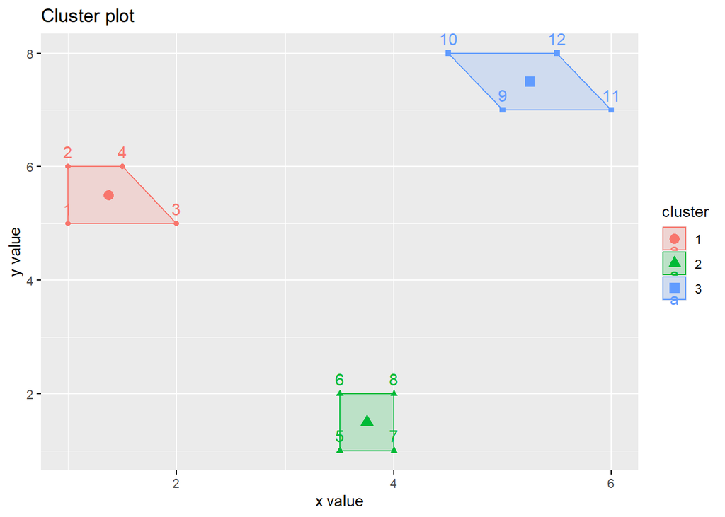

```r
res.hcut <- hcut(
data12,
hc_func = "agnes",
graph = TRUE,
hc_metric = "manhattan",
hc_method = "single",
k=3
)
fviz_cluster(res.hcut, stand=FALSE, ellipse.type = "convex")
```

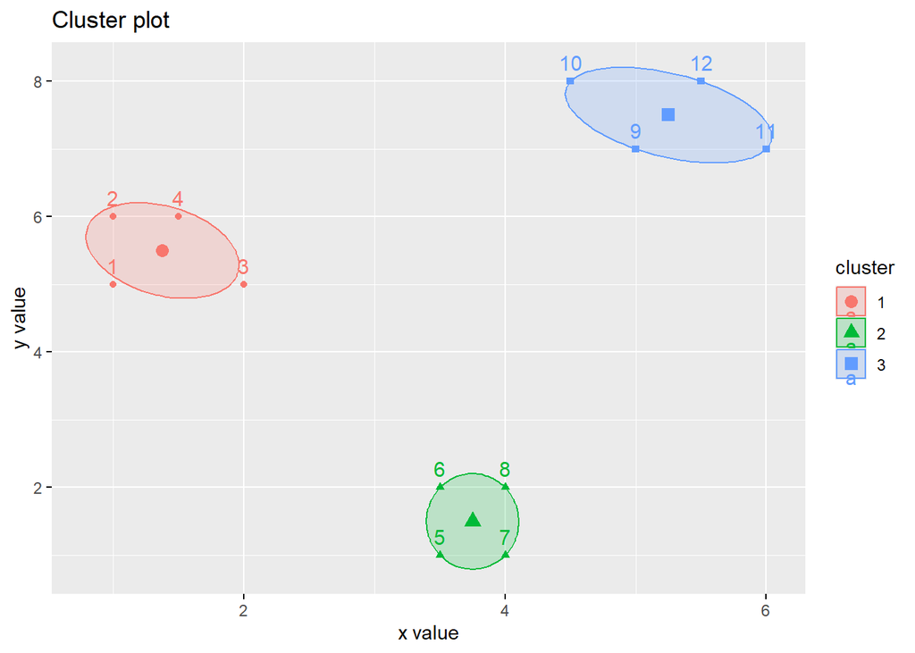

```r
fviz_cluster(
res.hcut,
stand = FALSE,
ellipse.level = 0.95,
ellipse.type = "confidence"
)
```

15. Effectuer (à la main) la CAH du jeu de données `data5` en conservant la distance du `city-block` mais en choisissant maintenant l’indice d’agrégation du lien maximum. Utiliser les fonctions R appropriées pour vérifier vos résultats.

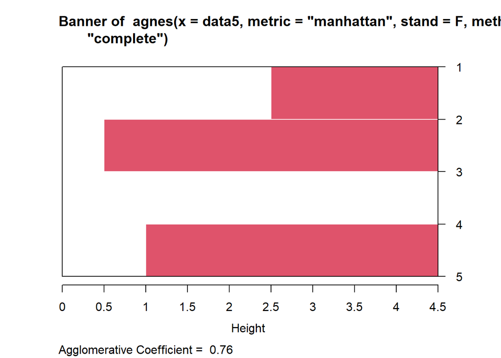

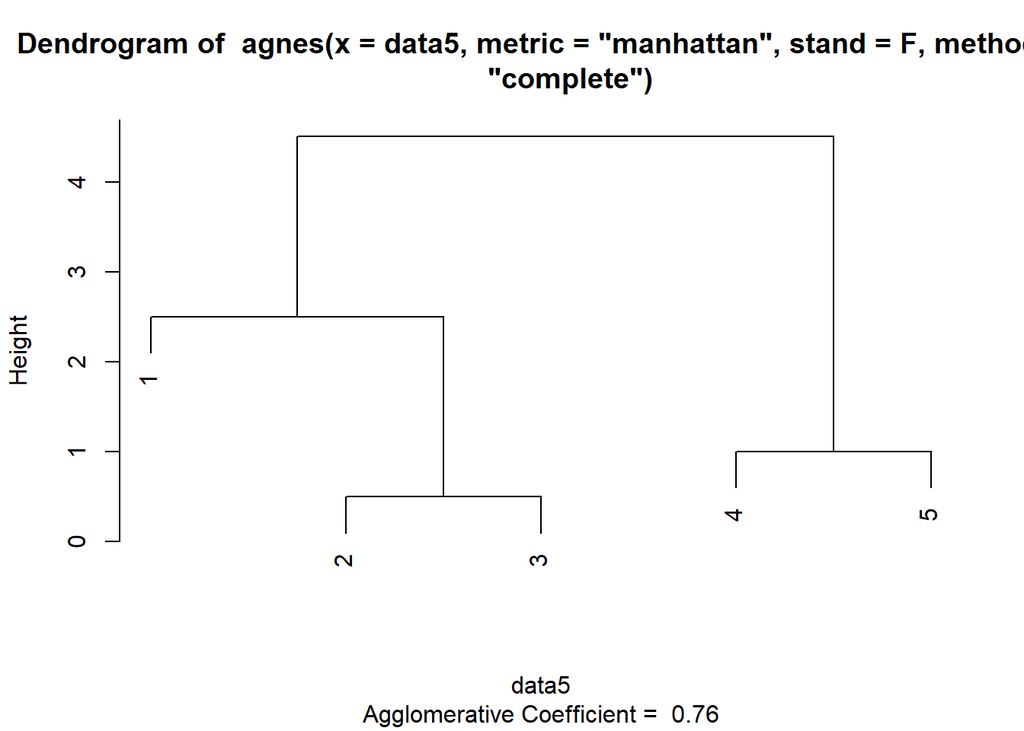

    ```r
    res.agnes <- agnes(data5, stand=F, metric="manhattan", method="complete")
    plot(res.agnes)
    ```

### Exercice 2. Classification à partir de données simulées

1. Que réalise la succession des commandes suivantes :

   Simule des données (3 échantillons de taille 100) selon 3 lois normales multivariées différentes

```r
library(mvtnorm)
# Matrices de variances covariances
sigma1 <- matrix(c(1,0,0,1), ncol=2)
sigma2 <- matrix(c(3,0,0,3), ncol=2)
sigma3 <- matrix(c(2,0,0,2), ncol=2)


A <- rmvnorm(n=100, mean=c(1,2), sigma=sigma1)
B <- rmvnorm(n=100, mean=c(7,8), sigma=sigma2)
C <- rmvnorm(n=100, mean=c(10,3), sigma=sigma3)

data.norm <- as.data.frame(rbind(A,B,C))
colnames(data.norm) <- c("X","Y")

groupe <- rep(c("A", "B", "C"),c(100,100,100))
data.norm$groupe <- as.factor(groupe)
summary(data.norm)
```

```
##        X                Y          groupe
##  Min.   :-1.334   Min.   :-1.185   A:100
##  1st Qu.: 1.658   1st Qu.: 1.937   B:100
##  Median : 6.795   Median : 3.333   C:100
##  Mean   : 5.905   Mean   : 4.362
##  3rd Qu.: 9.529   3rd Qu.: 7.132
##  Max.   :13.799   Max.   :12.006
```

2. Représenter le jeu de données ainsi obtenu :

```r
library(ggpubr)
ggscatter(
  data.norm,
  x = "X",
  y = "Y",
  color = "groupe",
  shape = "groupe",
  ggtheme = theme_gray(),
  size = 2,
  mean.point = TRUE,
  ellipse = T
)
```

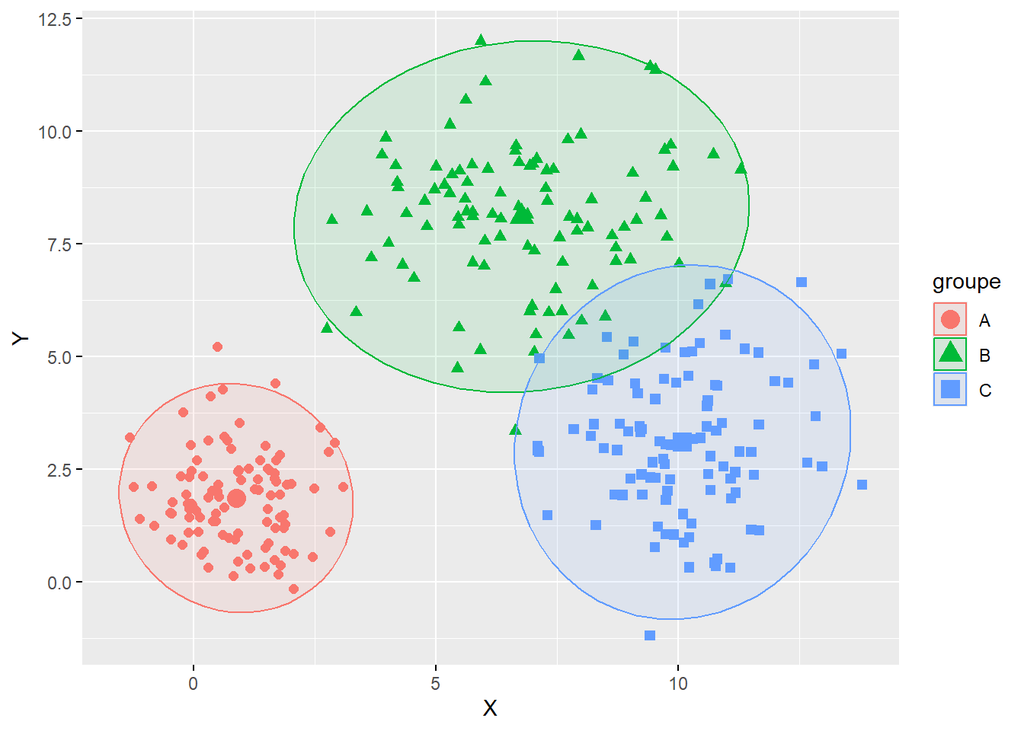

3. À l’aide de la fonction `hcut`, réaliser la CAH du jeu de données en choisissant l’indice de distance de Manhattan et la méthode d’agrégation du lien minimum. Représenter les classes obtenues sur un biplot à l’aide de la commande `fviz_cluster`. Que constate-ton ?

[figure not shown]

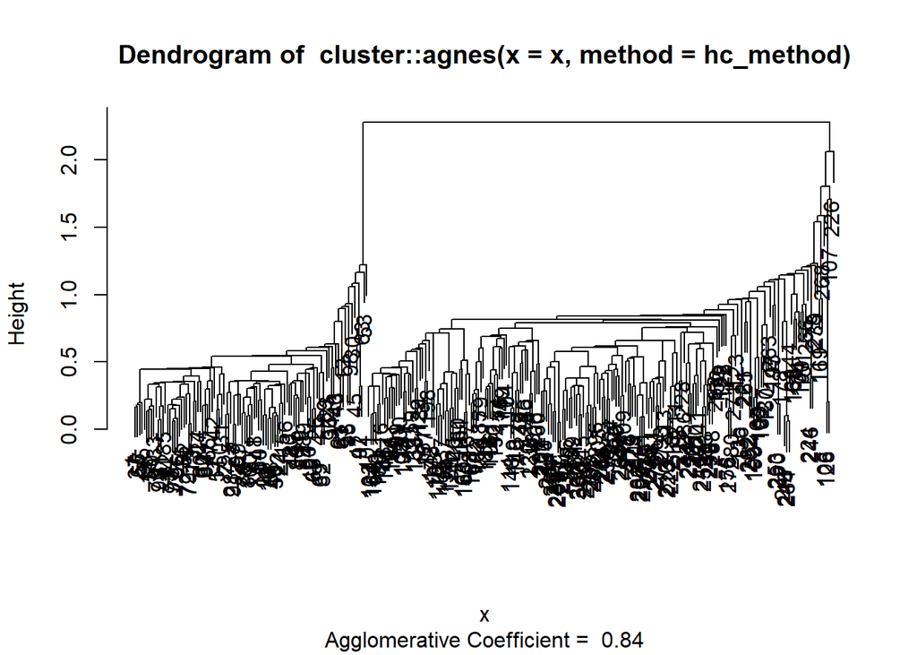

```r
library(factoextra)

# On demande une partition en 3 classes
res.hcut <- hcut(
  data.norm[,1:2],
  hc_func = "agnes",
  hc_metric = "manhattan",
  hc_method = "single",
  k=3
)
plot(res.hcut)
```

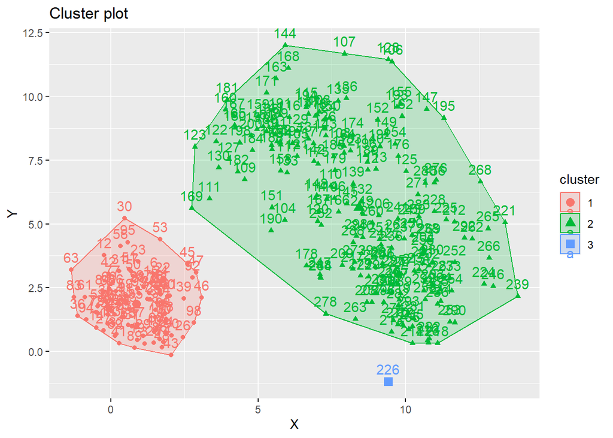

```r
fviz_cluster(res.hcut,  stand = FALSE, ellipse.type = "convex")
```

Ce ne sont pas du tout les classes attendues !

4. Recommencer avec la distance euclidienne et l’indice d’agrégation de Ward.

[figure not shown]

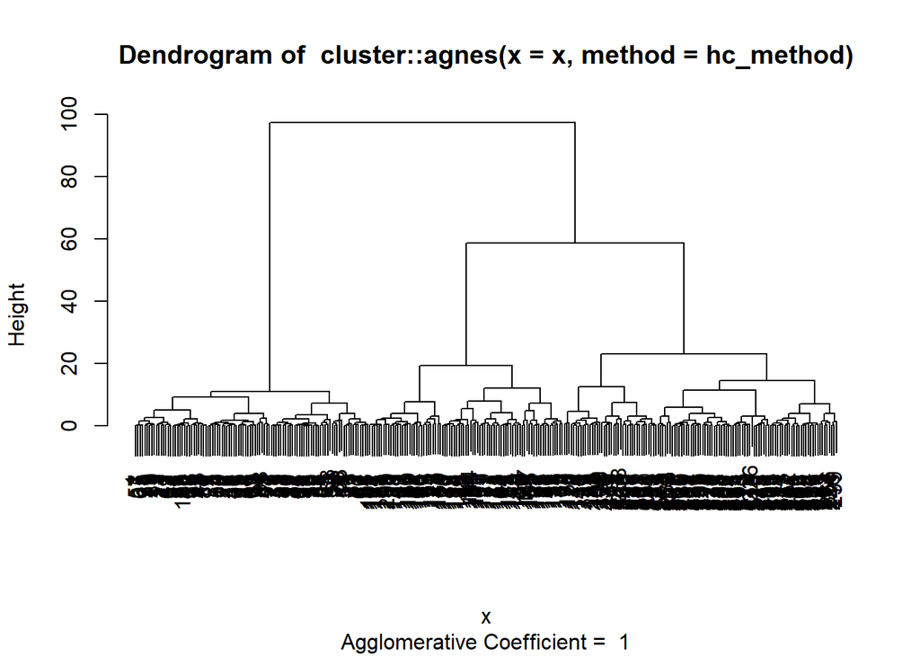

```r
res.hcut <- hcut(
  data.norm[,1:2],
  hc_func = "agnes",
  graph = TRUE,
  hc_metric = "euclidean",
  hc_method = "ward",
  k=3
)

plot(res.hcut)
```

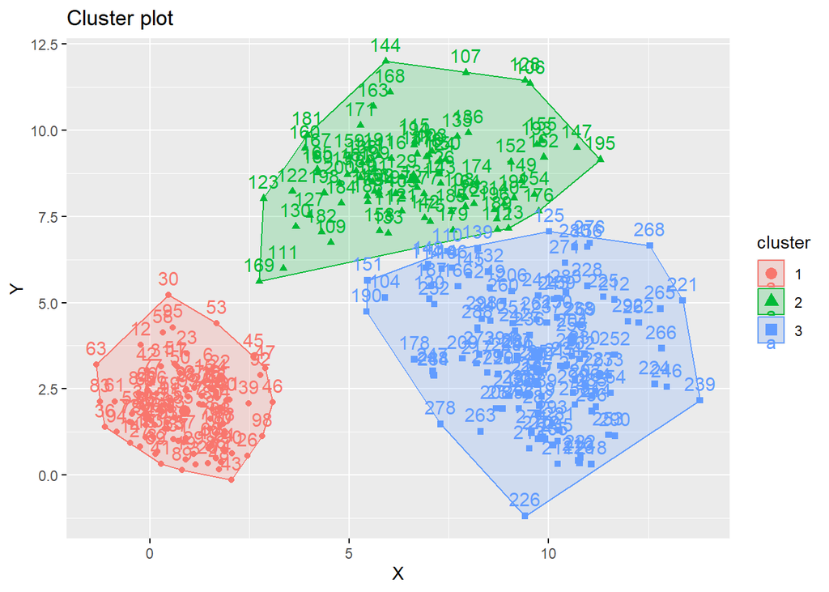

```r
fviz_cluster(res.hcut,  stand = FALSE, ellipse.type = "convex")
```

Les classes semblent être en accord avec les 3 lois normales multivariées

5. Construire un tableau croisé entre l’appartenance réelle des individus aux trois groupes et leur appartenance aux classes obtenues par la classification.

```r
table(res.hcut$cluster, data.norm$groupe)
```

```
##
##       A   B   C
##   1 100   0   0
##   2   0  83   0
##   3   0  17 100
```

On observe un petit mélange entre les groupes 2 et 3, ceux qui étaient les plus proches dans la représentation graphique en 2 dimensions